# Baseball Analytics

Ryan Mavilia

April 1, 2018

```r
# make sure you write the path to your sqlite path here
db <- DBI::dbConnect(RSQLite::SQLite(), "lahman2016.sqlite")
library(dplyr)
```

```r
library(tidyr)
library(ggplot2)
```

Here we connect to the baseball database and import libraries which will be needed later on.

```sql
SELECT MAX(100.0 * team.W / team.G) AS winPercentage, SUM(sal.salary) AS payroll, team.W, team.G, team.yearID, team.teamID
FROM Teams AS team, Salaries AS sal
INNER JOIN teamsFranchises AS teamfran ON
      team.yearID = sal.yearID
      AND team.teamID = sal.teamID
GROUP BY sal.yearID, sal.teamID
```

I run an SQL query which will ask the database to return a table with the calculated payroll & win percentages for the different teams on a per year basis.

```r
payroll_df %>%
    head()
```

|  | winPercentage | payroll | W | G | yearID | teamID |
| --- | --- | --- | --- | --- | --- | --- |
| 1 | 40.74074 | 1776840000 | 66 | 162 | 1985 | ATL |
| 2 | 51.55280 | 1387285440 | 83 | 161 | 1985 | BAL |
| 3 | 49.69325 | 1307707200 | 81 | 163 | 1985 | BOS |
| 4 | 55.55556 | 1731347280 | 90 | 162 | 1985 | CAL |
| 5 | 52.14724 | 1181541360 | 85 | 163 | 1985 | CHA |
| 6 | 47.53086 | 1524350040 | 77 | 162 | 1985 | CHN |

# Payroll distribution

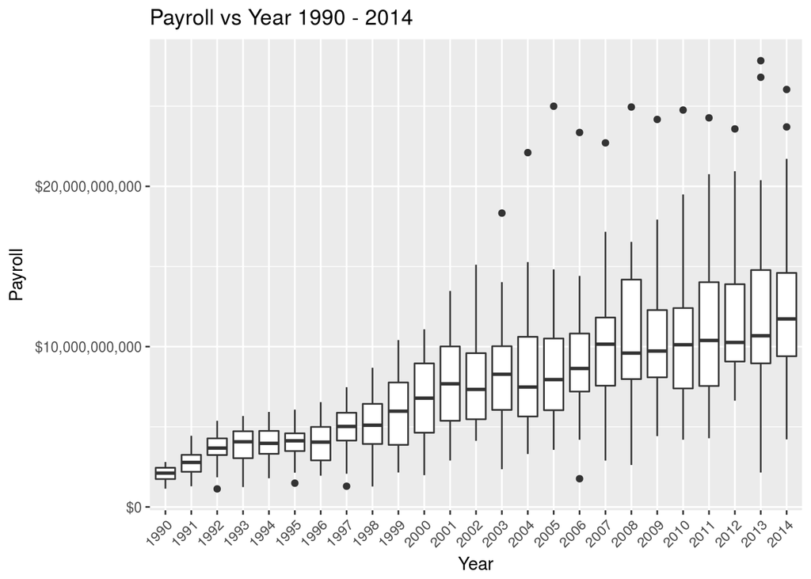

```r
payroll_df %>%
  group_by(yearID) %>%
    filter(1990 <= yearID & yearID <= 2014) %>%
    ggplot(mapping=aes(y=payroll, x=factor(yearID))) +
    geom_boxplot() +
    xlab("Year") +
    ylab("Payroll") +
    ggtitle("Payroll vs Year 1990 - 2014") +
    scale_y_continuous(labels = scales::dollar) +
    theme(axis.text.x = element_text(angle = 45, hjust = 1))
```

In order to graph the payroll in regards to the year we must first filter out years we don’t want which is anything outside of 1990-2014. After that we create a boxplot with payroll as our Y-axis and yearID as our X-axis (using the factor because R reads yearID as a continuous variable). We also label the axes, title, add dolar signs to the payroll labels, and rotate the years to make them easier to read.

As time goes on payrolls for the league have increased in both mean and spread. We can see how large the boxes get towards the the end of the 2000’s and that there is an upward trend. I would say that payroll increased greatly from 1990 to 2007 and then evened out which reflects the projects reflection on how things evened out after 2005 when other teams “caught up”.

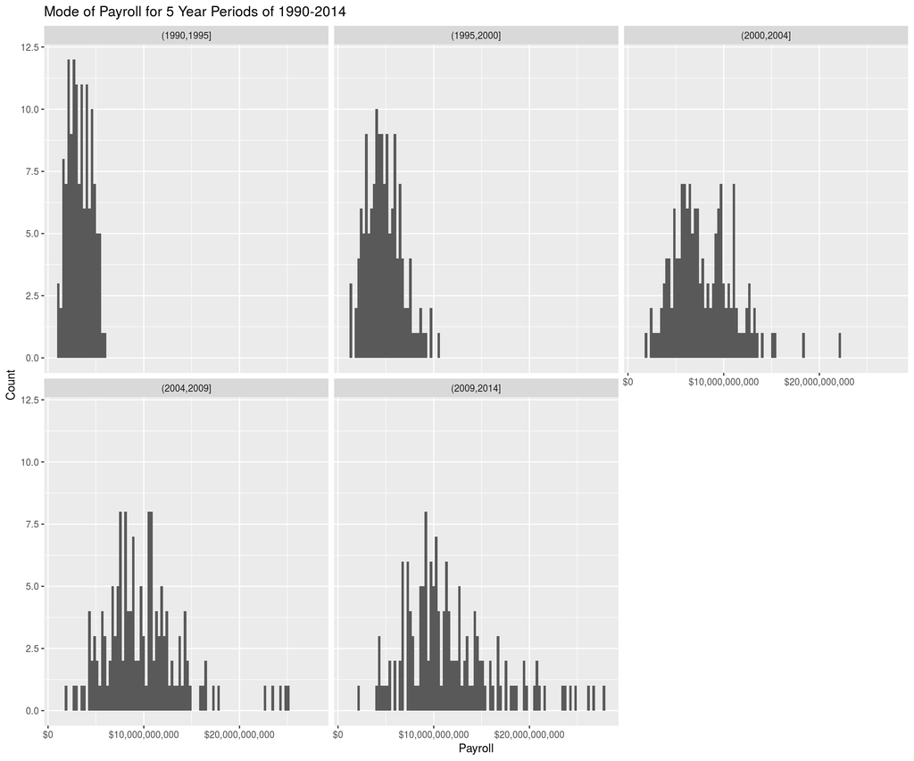

```r
payroll_df <- filter(payroll_df, 1990 <= yearID & yearID <= 2014)
plot1 <- payroll_df %>%
  mutate(yearRange = cut(payroll_df$yearID, breaks = 5)) %>%
  group_by(yearRange) %>%
  ggplot(mapping = aes(x=payroll)) +
  geom_histogram(bins = 100) +
  scale_x_continuous(labels = scales::dollar) +
  xlab(label = "Payroll") +
  ylab(label="Count")+
  ggtitle("Mode of Payroll for 5 Year Periods of 1990-2014")
plot1 + facet_wrap(~yearRange)
```

## Correlation between payroll and winning percentage

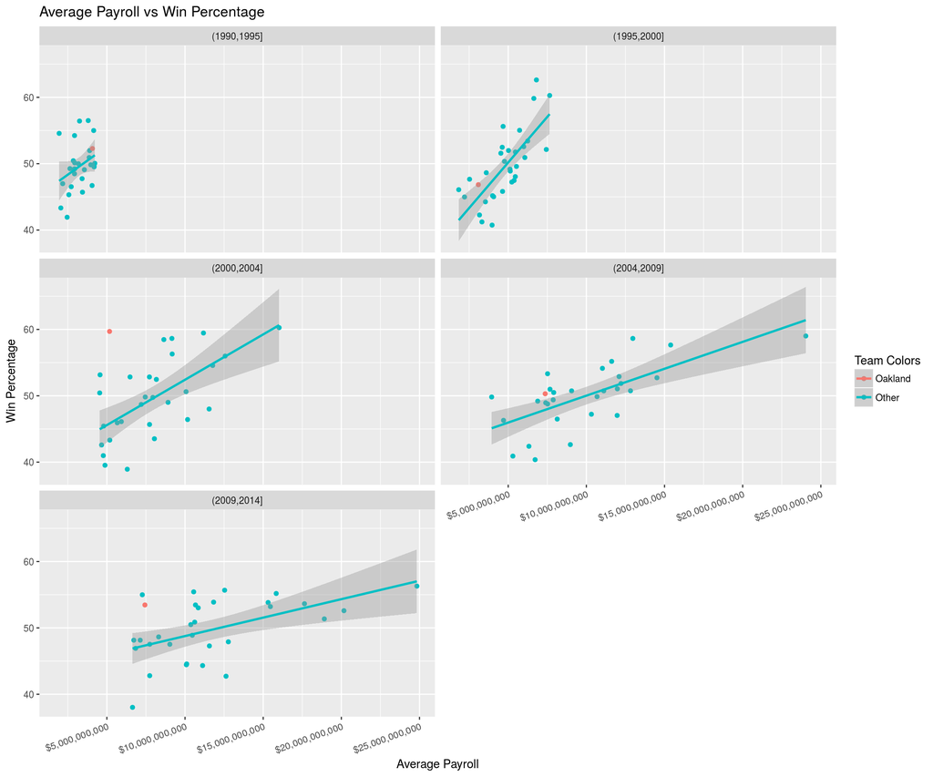

```r
payroll_df$yearRange <- cut(payroll_df$yearID, breaks=5)

plot1 <- payroll_df %>%
  group_by(teamID, yearRange) %>%
  summarize(m = mean(payroll), n=mean(winPercentage))%>%
    ggplot(mapping=aes(x=m, y=n, col = ifelse(teamID=="OAK", "Oakland", "Other"))) +
      geom_point() +
      geom_smooth(method=lm) +
     labs(color='Team Colors') +
  theme(axis.text.x = element_text(angle = 20, hjust = 1)) +
    scale_x_continuous(labels = scales::dollar) +
  ylab(label="Win Percentage") +
  xlab(label="Average Payroll") +
    ggtitle("Average Payroll vs Win Percentage")
plot1+facet_wrap(~yearRange, nrow = 3, ncol = 2)
```

I used geom_smooth and scatter plots to show the regression lines of pay vs winningness over the 5 periods between 1990-2014.

# Data transformations

## Standardization across years

```r
payroll_df <- payroll_df %>%
  group_by(yearID) %>%
  mutate(standardized_payroll = (payroll-mean(payroll))/sd(payroll))
payroll_df[,c(5:8)]
```

| yearID | teamID | yearRange | standardized_payroll |
| --- | --- | --- | --- |
| 1990 | ATL | (1990,1995] | -0.667275495 |
| 1990 | BAL | (1990,1995] | -1.959860656 |
| 1990 | BOS | (1990,1995] | 0.924213308 |
| 1990 | CAL | (1990,1995] | 1.232197943 |
| 1990 | CHA | (1990,1995] | -2.009858611 |
| 1990 | CHN | (1990,1995] | -0.914237831 |
| 1990 | CIN | (1990,1995] | -0.716456076 |
| 1990 | CLE | (1990,1995] | -0.685436686 |
| 1990 | DET | (1990,1995] | 0.138098439 |
| 1990 | HOU | (1990,1995] | 0.333430987 |

[output cut: 718 more lines]

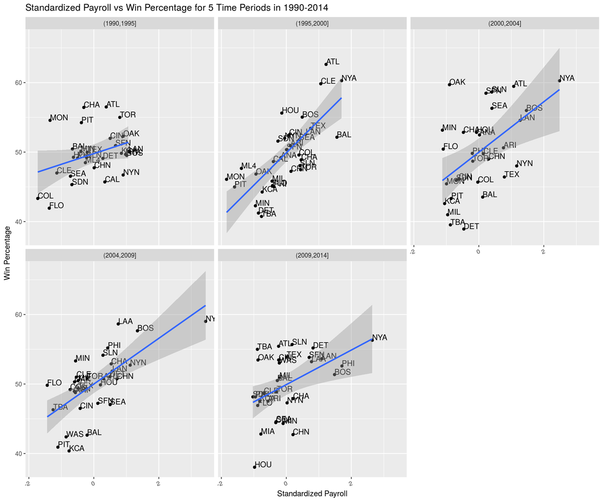

```r
plot5 <- payroll_df %>%
  group_by(teamID, yearRange) %>%
  summarise(n = mean(standardized_payroll), m = mean(winPercentage)) %>%
    ggplot(aes(x=n, y=m)) +
      geom_point() +
      geom_text(aes(label=teamID),hjust=0, vjust=0) +
      geom_smooth(method=lm) +
  theme(axis.text.x = element_text(angle = 20, hjust = 1)) +
  xlab(label="Standardized Payroll") +
  ylab(label="Win Percentage") +
    ggtitle("Standardized Payroll vs Win Percentage for 5 Time Periods in 1990-2014")
plot5+facet_wrap(~yearRange)
```

Here I have recomoputed the same plots from problem 4 with the new standardized payroll data.

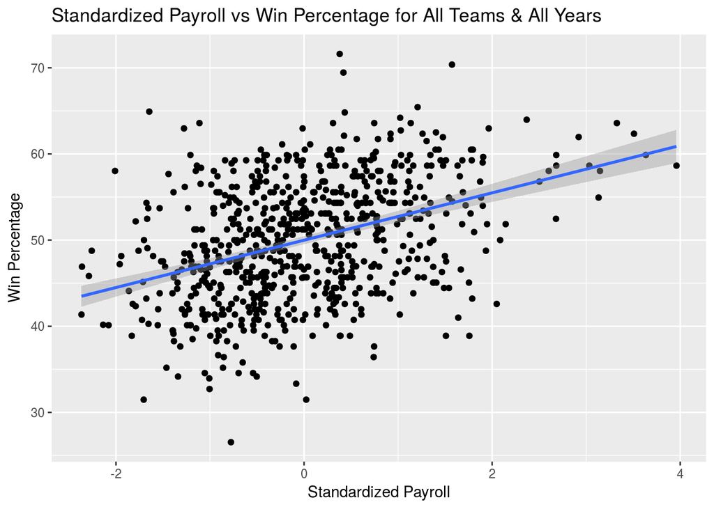

```r
payroll_df %>%
  ggplot(mapping = aes(x=standardized_payroll, y = winPercentage)) +
  geom_point() +
  geom_smooth(method = lm)+
  xlab(label="Standardized Payroll") +
  ylab(label="Win Percentage") +
    ggtitle("Standardized Payroll vs Win Percentage for All Teams & All Years")
```

Here I created a plot using all of the points and we can see that as spending increases the win percentage increases as well.

```r
payroll_df <- payroll_df %>%
  mutate(expected_win_pct = (50 + 2.5 * standardized_payroll)) %>%
  mutate(efficiency = winPercentage - expected_win_pct)

payroll_df
```

| winPercentage | payroll | W | G | yearID | teamID | yearRange | standardized_payroll | expected_win_pct | efficiency |
| --- | --- | --- | --- | --- | --- | --- | --- | --- | --- |
| 40.12346 | 1746660120 | 65 | 162 | 1990 | ATL | (1990,1995] | -0.667275495 | 48.33181 | -8.20835447 |
| 47.20497 | 1161610080 | 76 | 161 | 1990 | BAL | (1990,1995] | -1.959860656 | 45.10035 | 2.10462058 |
| 54.32099 | 2466999960 | 88 | 162 | 1990 | BOS | (1990,1995] | 0.924213308 | 52.31053 | 2.01045438 |
| 49.38272 | 2606400000 | 80 | 162 | 1990 | CAL | (1990,1995] | 1.232197943 | 53.08049 | -3.69777881 |
| 58.02469 | 1138980000 | 94 | 162 | 1990 | CHA | (1990,1995] | -2.009858611 | 44.97535 | 13.04933789 |
| 47.53086 | 1634880000 | 77 | 162 | 1990 | CHN | (1990,1995] | -0.914237831 | 47.71441 | -0.18354123 |
| 56.17284 | 1724400000 | 91 | 162 | 1990 | CIN | (1990,1995] | -0.716456076 | 48.20886 | 7.96397970 |
| 47.53086 | 1738440000 | 77 | 162 | 1990 | CLE | (1990,1995] | -0.685436686 | 48.28641 | -0.75554409 |
| 48.76543 | 2111188560 | 79 | 162 | 1990 | DET | (1990,1995] | 0.138098439 | 50.34525 | -1.57981400 |
| 46.29630 | 2199600000 | 75 | 162 | 1990 | HOU | (1990,1995] | 0.333430987 | 50.83358 | -4.53728117 |

[output cut: 718 more lines]

I’ve created the expected win percentage and efficiency calculations based on the formulas given using the dplyr mutate function.

## Spending efficiency

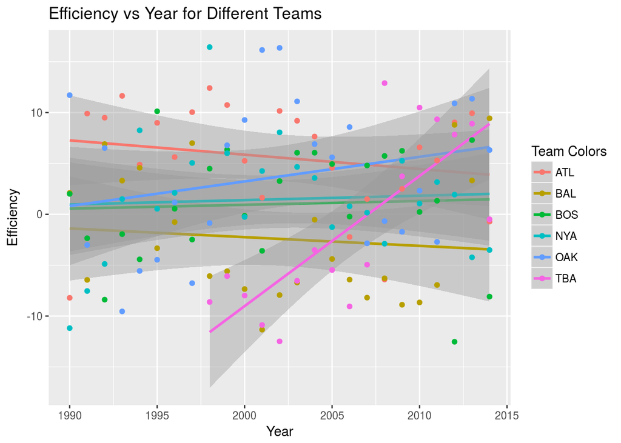

```r
payroll_df %>%
  filter(teamID %in% c("OAK", "BOS", "BAL", "NYA", "ATL", "TBA")) %>%
  ggplot(mapping = aes(x=yearID, y=efficiency, color = teamID)) +
  geom_smooth(method=lm) +
  geom_point() +
  labs(color='Team Colors') +
  xlab(label="Year") +
  ylab(label="Efficiency") +
  ggtitle("Efficiency vs Year for Different Teams")
```

Here I’ve created a plot with the efficiency mapped against the year for the 5 teams mentioned in the documentation as well as the Baltimore Orioles since they are my favorite team. I used geom_smooth as specified and also provided coloring.

The Oakland Athletics did extremely well during the MoneyBall year. This shows just how well their strategy worked for them before others caught up such as Tampa Bay in 2010. I think this would do really well as a 3D graph with another factor added in such as team size, batting average, etc. so that we can see how efficiency interleaves with other factors.